# STAMP-Report: PulseOx_Forwarding_System

*This report was generated by the [MDCF Architect](http://santoslab.org/pub/mdcf-architect/) on November 5, 2014 at 4:15 PM*

## Background

### Context

Clinicians want to view physiological parameters on a display not physically connected to a physiological monitor.

### Assumptions

- There are no alarms that need forwarding.

### Abbreviations

**KVO**

Keep Vein Open: A minimal rate (of drug administration)

## Fundamentals

### System Boundaries

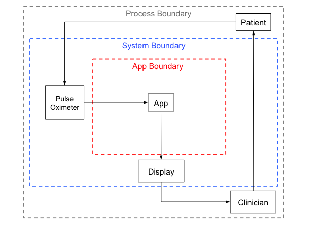

System Boundary

### Accident Levels

1. **DeathOrInjury**: A human is killed or seriously injured.

### Accidents

1. **PatientHarmed**: Patient is killed or seriously injured. [DeathOrInjury]

### Hazards

1. **BadInfoDisplayed**: Incorrect information is sent to the display. [PatientHarmed]
2. **MissedAlarm**: An alarm that should be displayed is not. [PatientHarmed]

### Safety Constraints

1. **ShowGoodInfo**: The app must accurately inform the display of the status of the patient’s vital signs. [BadInfoDisplayed]
2. **ShowAllAlarms**: The app must display all alarms that are clinically necessary. [MissedAlarm]

### Control Actions

1. spo2_to_display: ICEpoInterface -> PulseOx_Display_Process (Integer)
2. alarm_to_display: PulseOx_Logic_Process -> PulseOx_Display_Process (Object)

### Process Model

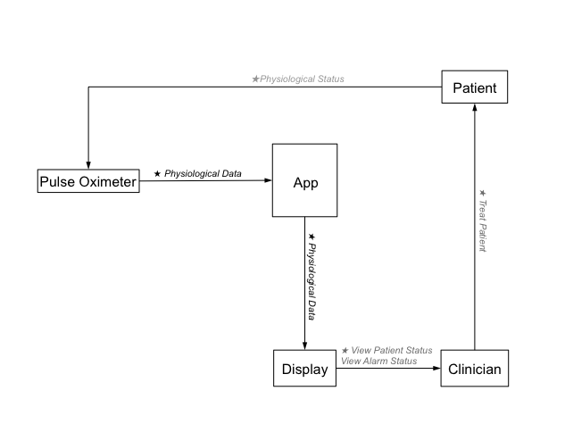

Process Model

## Unsafe Control Actions

| Control Action | Providing | Not Providing | Applied Too Long | Stopped Too Soon | Early | Late |
| --- | --- | --- | --- | --- | --- | --- |
| spo2_to_display |  |  |  |  |  |  |
| alarm_to_display |  | MissedAlarm (Bad SpO2) |  |  |  |  |

| Control Action | Value Too High | Value Too Low |
| --- | --- | --- |
| spo2_to_display | BadInfoDisplayed (Bad SpO2) |  |

## Unsafe Control Action Causes and Compensations

#### spo2_to_display

- **VALUEHIGH**: Bad SpO2
  - Cause: Incorrect SpO2 values are sent to the display
  - Compensation: None

#### alarm_to_display

- **NOTPROVIDING**: Bad SpO2
  - Cause: The SpO2 values from the pulse oximeter are too high, so the alarm is missed
  - Compensation: None